# Anova Homework

Michelle

11/11/2021

# Data description:

For this exercise, we will be looking at brood size and fertilization in *C. elegans*. The measurements taken were:

**Brood size**- number of progeny laid by one worm in one day  
**Fertilized**- number of progeny laid that are fertilized embryos

For this first part, we will be looking at the brood sizes in the WT N2 strain (WT), in single mutants (A), and in double mutants(A;B). There are 30 replicates of each condition.

# Q1

First, load the data and create subsets of the individual genotypes. Calculate the percent fertilization ($fertilized/brood size$).

```r
anova_data <- as.data.frame(read.csv("hw_anova.csv"))
anova_data$genotype<- as.factor(anova_data$genotype)
anova_data$brood_size<- as.numeric(anova_data$brood_size)
anova_data$fertilized<- as.numeric(anova_data$fertilized)
anova_data$percent_fertilized<- round(anova_data$fertilized/anova_data$brood_size, digits=2)

anova_wt<- subset(anova_data, genotype=="WT")
anova_A<- subset(anova_data, genotype=="A")
anova_AB<- subset(anova_data, genotype=="A;B")
```

Use boxplots to plot the data. For readability, make sure that the WT is the leftmost boxplot, followed by the single mutant and then the double mutant.

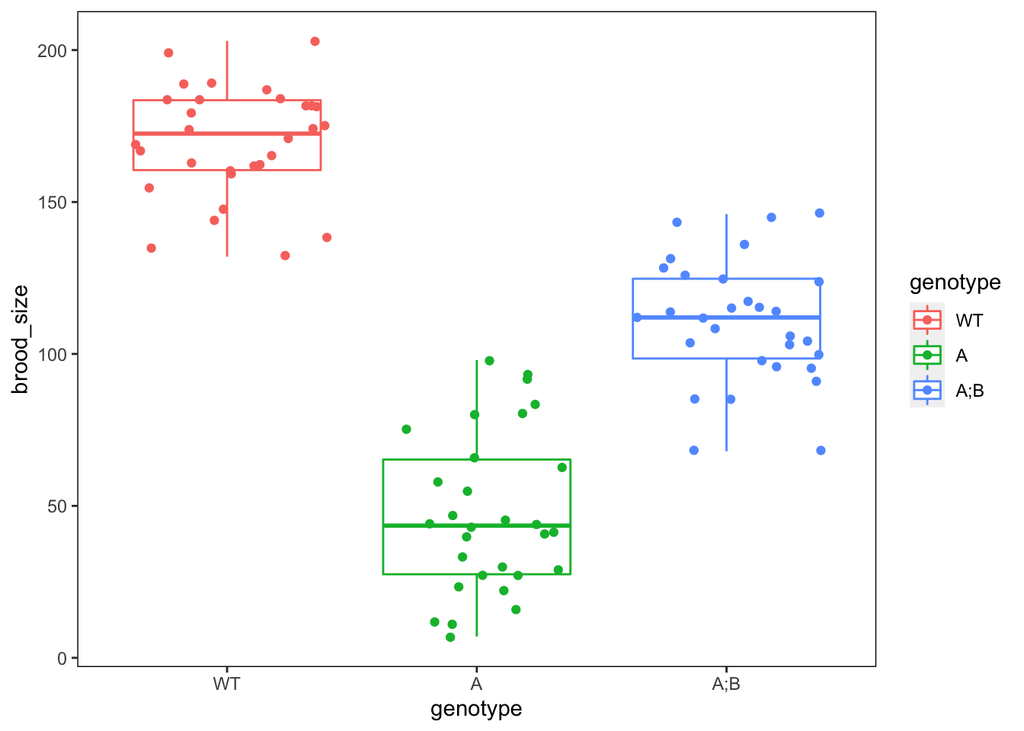

```r
anova_data$genotype<- factor(anova_data$genotype, levels=c("WT", "A", "A;B"))

anova_data_boxplot<- ggplot(anova_data, aes(x= genotype, y= brood_size,
                                       color= genotype))+
  geom_boxplot()+
  geom_jitter()+
  theme(panel.background=element_blank(),
        strip.background = element_blank(),
        strip.placement = "outside",
        strip.text=element_blank(),
        panel.border=element_rect(colour="black",fill=NA))
anova_data_boxplot
```

.  
In order to be able to utilize an ANOVA, two requirements must be fulfilled:  
1) the data must be normally distributed.  
2) the variation must be the same between groups.

Use the `shapiro.test()` function to determine if the measurements from the different groups are normally distributed. Use histogram plots to visualize the distributions.

```r
shapiro.test(anova_wt$brood_size)
```

```
##
##  Shapiro-Wilk normality test
##
## data:  anova_wt$brood_size
## W = 0.96664, p-value = 0.4517
```

```r
shapiro.test(anova_A$brood_size)
```

```
##
##  Shapiro-Wilk normality test
##
## data:  anova_A$brood_size
## W = 0.9485, p-value = 0.1541
```

```r
shapiro.test(anova_AB$brood_size)
```

```
##
##  Shapiro-Wilk normality test
##
## data:  anova_AB$brood_size
## W = 0.97547, p-value = 0.6965
```

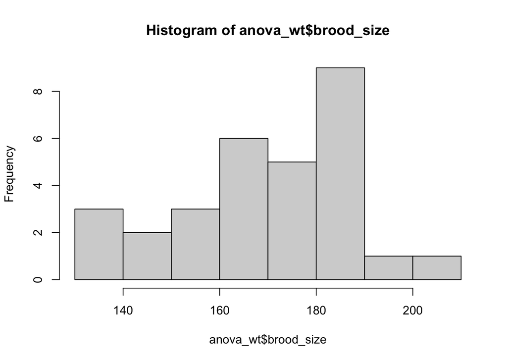

```r
hist(anova_wt$brood_size)
```

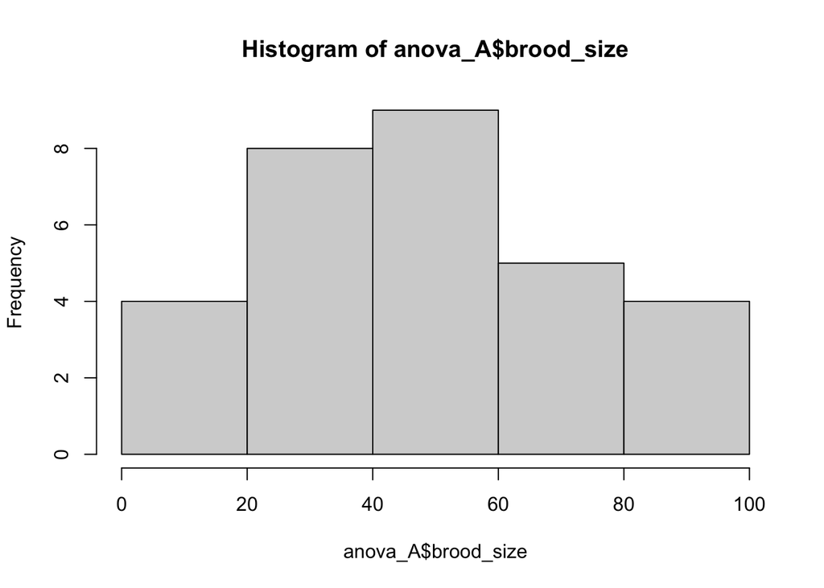

```r
hist(anova_A$brood_size)
```

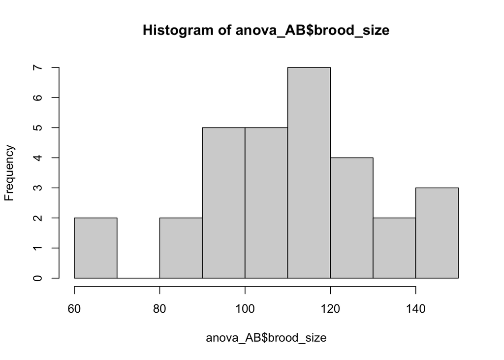

```r
hist(anova_AB$brood_size)
```

.  
Determine if the variation is the same between the groups. You can use the `var.test()` function.

```r
var.test(anova_wt$brood_size, anova_A$brood_size)
```

```
##
##  F test to compare two variances
##
## data:  anova_wt$brood_size and anova_A$brood_size
## F = 0.48311, num df = 29, denom df = 29, p-value = 0.05467
## alternative hypothesis: true ratio of variances is not equal to 1
## 95 percent confidence interval:
##  0.2299411 1.0150023
## sample estimates:
## ratio of variances
##          0.4831053
```

```r
var.test(anova_wt$brood_size, anova_AB$brood_size)
```

```
##
##  F test to compare two variances
##
## data:  anova_wt$brood_size and anova_AB$brood_size
## F = 0.81212, num df = 29, denom df = 29, p-value = 0.5789
## alternative hypothesis: true ratio of variances is not equal to 1
## 95 percent confidence interval:
##  0.386541 1.706263
## sample estimates:
## ratio of variances
##          0.8121209
```

```r
var.test(anova_A$brood_size, anova_AB$brood_size)
```

```
##
##  F test to compare two variances
##
## data:  anova_A$brood_size and anova_AB$brood_size
## F = 1.681, num df = 29, denom df = 29, p-value = 0.1679
## alternative hypothesis: true ratio of variances is not equal to 1
## 95 percent confidence interval:
##  0.8001174 3.5318648
## sample estimates:
## ratio of variances
##           1.681043
```

⇒ **What is the statistic used by var.test()? What is the null hypothesis of this test?**

*The function performs an F test that compares the variances of two samples from normal populations.*

⇒ **Are the assumptions regarding data being normally distributed and variance being equal met?**

*Yes, the data are normally distributed and the variances are similar.*

## Q2: Planned vs unplanned

⇒ **Explain whether this experiment should be treated as a PLANNED or UNPLANNED dataset. How would the analysis differ between these two scenarios?**

*Datasets that contain a “control” treatments are treated as “planned” experiments, in which different treatments are compared to the control as a reference.*

*Analysis for an “unplanned” dataset looks for total variation, followed by a Tukey Honest Significant Difference test, which makes all pairwise comparisons to determine which pairs of samples, if any, show a significant difference.*

## Q3: Sum of Squares and F-statistic

Calculate the sum of squares for $SS_{error}$ and $SS_{group}$. Recall the formulas:

$$SS_{total}~=SS_{error}+SS_{group}$$

$$SSerror=\sum_{i}\sum_{j}(Y−\overline{Y}_i)^{2}$$
$$SS_{group}=\sum_{i}n_{i}(\overline{Y}_i−\overline{Y})^{2}$$

```r
anova_wt_sum<- sum((anova_wt$brood_size - mean(anova_wt$brood_size))^2)
anova_A_sum <- sum((anova_A$brood_size - mean(anova_A$brood_size))^2)
anova_AB_sum <- sum((anova_AB$brood_size - mean(anova_AB$brood_size))^2)

SS_error <- anova_wt_sum + anova_A_sum + anova_AB_sum

SS_group <- length(anova_wt$brood_size) * (mean(anova_wt$brood_size) - mean(anova_data$brood_size))^2 +
  length(anova_A$brood_size) * (mean(anova_A$brood_size) - mean(anova_data$brood_size))^2 +
  length(anova_AB$brood_size) * (mean(anova_AB$brood_size) - mean(anova_data$brood_size))^2
```

Calculate the F-statistic and the p-value using the `pf() function.` Recall that:

$$F=\frac{MS_{groups}}{MS_{error}}$$
$$MS_{groups}=\frac{SS_{groups}}{df_{groups}}$$
$$MS_{error}=\frac{SS_{error}}{df_{error}}$$

```r
df_error <- ( length(anova_wt$brood_size) - 1
                      + length(anova_A$brood_size) - 1
                      + length(anova_AB$brood_size) - 1)
MS_error <- SS_error/df_error

df_group <- 3-1
MS_group <- SS_group/df_group

Fstat <- MS_group/MS_error

# p-value using CDF for F-statistic
pf(Fstat,df_group, df_error, lower.tail = F )
```

```
## [1] 6.165467e-36
```

## Q4: Planned

Assume the data is a planned experiment. Use the `lm()` function to perform the analysis. Remember to use the summary() function on the results of the `lm()` function to look at the p-values of the model and also the individual comparisons.

```r
# summary for lm of brood_size ~ genotype
summary(lm(anova_data$brood_size ~ anova_data$genotype))
```

```
##
## Call:
## lm(formula = anova_data$brood_size ~ anova_data$genotype)
##
## Residuals:
##     Min      1Q  Median      3Q     Max
## -42.467 -14.492  -1.667  14.133  50.500
##
## Coefficients:
##                        Estimate Std. Error t value Pr(>|t|)
## (Intercept)             169.867      3.975   42.73   <2e-16 ***
## anova_data$genotypeA   -122.367      5.621  -21.77   <2e-16 ***
## anova_data$genotypeA;B  -59.400      5.621  -10.57   <2e-16 ***
## ---
## Signif. codes:  0 '***' 0.001 '**' 0.01 '*' 0.05 '.' 0.1 ' ' 1
##
## Residual standard error: 21.77 on 87 degrees of freedom
## Multiple R-squared:  0.8449, Adjusted R-squared:  0.8413
## F-statistic:   237 on 2 and 87 DF,  p-value: < 2.2e-16
```

Use the `anova()` function on the results of the `lm()` function to look at the different $SS$ values and the p-value of the results.

```r
# anova on lm
anova(lm(anova_data$brood_size ~ anova_data$genotype))
```

```
## Analysis of Variance Table
##
## Response: anova_data$brood_size
##                     Df Sum Sq Mean Sq F value    Pr(>F)
## anova_data$genotype  2 224668  112334  236.99 < 2.2e-16 ***
## Residuals           87  41238     474
## ---
## Signif. codes:  0 '***' 0.001 '**' 0.01 '*' 0.05 '.' 0.1 ' ' 1
```

⇒ **Is the model significant overall? How about the different groups: are they significantly different from the control? If not, explain how this is possible.**

*The model is significant overall, and all the groups are significantly different from each other.*

## Q5: Unplanned

Assume the data are from an unplanned experiment. Use the `aov()` function to perform the analysis.

```r
# aov for brood_size ~ genotype
aov(anova_data$brood_size ~ anova_data$genotype)
```

```
## Call:
##    aov(formula = anova_data$brood_size ~ anova_data$genotype)
##
## Terms:
##                 anova_data$genotype Residuals
## Sum of Squares            224667.62  41238.43
## Deg. of Freedom                   2        87
##
## Residual standard error: 21.77166
## Estimated effects may be unbalanced
```

Use the `tukeyHSD()` function on the results of `aov()` to perform the Tukey-Kramer test to look at all pairwise comparisons.

```r
# tukey's honest significant difference test
TukeyHSD(aov(anova_data$brood_size ~ anova_data$genotype))
```

```
##   Tukey multiple comparisons of means
##     95% family-wise confidence level
##
## Fit: aov(formula = anova_data$brood_size ~ anova_data$genotype)
##
## $`anova_data$genotype`
##              diff        lwr        upr p adj
## A-WT   -122.36667 -135.77082 -108.96251     0
## A;B-WT  -59.40000  -72.80415  -45.99585     0
## A;B-A    62.96667   49.56251   76.37082     0
```

⇒ **What do these results tell you?**

⇒ **What is a possible biological interpretation of these results?** *The single mutant has a reduced brood size phenotype that is significantly different than the N2. The double mutant significantly rescues the reduced brood size phenotype, but is still significantly lower than the N2 brood size.*  
Once you have performed the ANOVA, you can check your assumption of normality by checking to see if the ANOVA residuals are normally distributed.

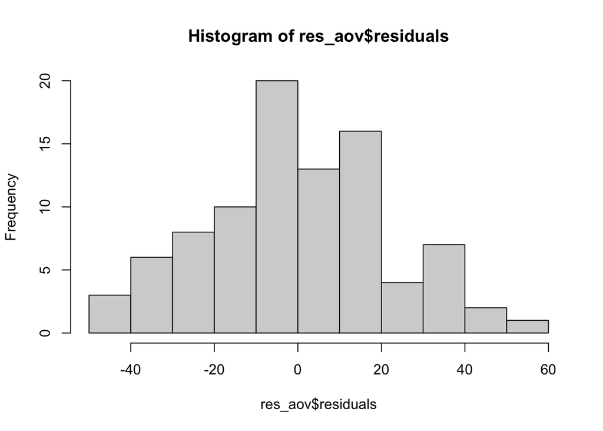

```r
res_aov <- aov(brood_size ~ genotype,
               data = anova_data)

hist(res_aov$residuals)
```

```r
shapiro.test(res_aov$residuals)
```

```
##
##  Shapiro-Wilk normality test
##
## data:  res_aov$residuals
## W = 0.98715, p-value = 0.5251
```

## Q6

Now we will look at the fertilization phenotype.

Plot the percent fertilization:

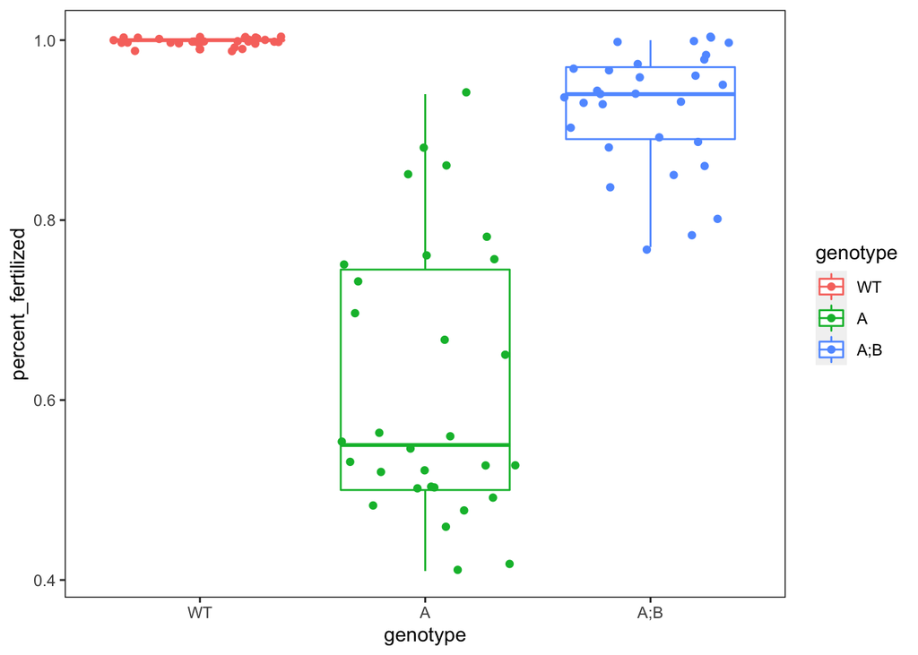

```r
percent_fertilized_boxplot<- ggplot(anova_data, aes(x= genotype, y= percent_fertilized,
                                       color= genotype))+
  geom_boxplot()+
  geom_jitter()+
  theme(panel.background=element_blank(),
        strip.background = element_blank(),
        strip.placement = "outside",
        strip.text=element_blank(),
        panel.border=element_rect(colour="black",fill=NA))
percent_fertilized_boxplot
```

.  
Check for normality:

```r
shapiro.test(anova_wt$percent_fertilized)
```

```
##
##  Shapiro-Wilk normality test
##
## data:  anova_wt$percent_fertilized
## W = 0.4044, p-value = 5.981e-10
```

```r
shapiro.test(anova_A$percent_fertilized)
```

```
##
##  Shapiro-Wilk normality test
##
## data:  anova_A$percent_fertilized
## W = 0.89985, p-value = 0.008327
```

```r
shapiro.test(anova_AB$percent_fertilized)
```

```
##
##  Shapiro-Wilk normality test
##
## data:  anova_AB$percent_fertilized
## W = 0.89714, p-value = 0.007153
```

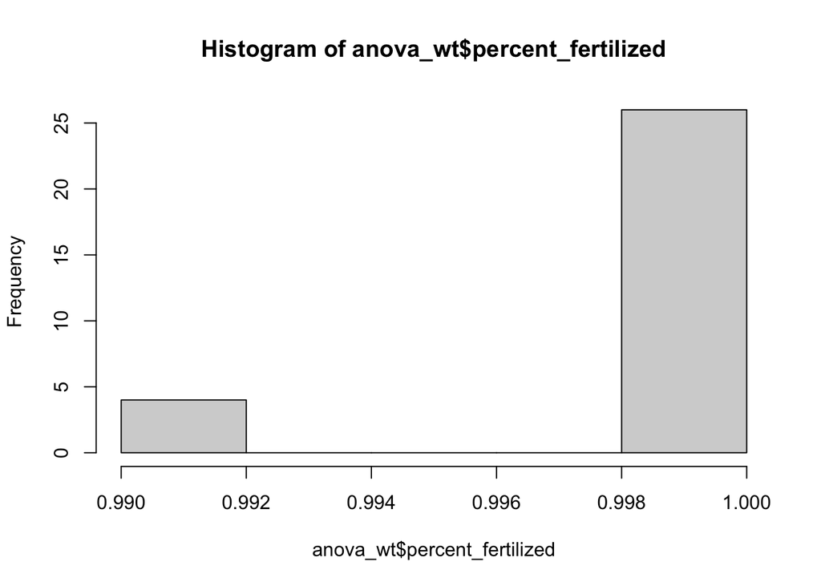

```r
hist(anova_wt$percent_fertilized)
```

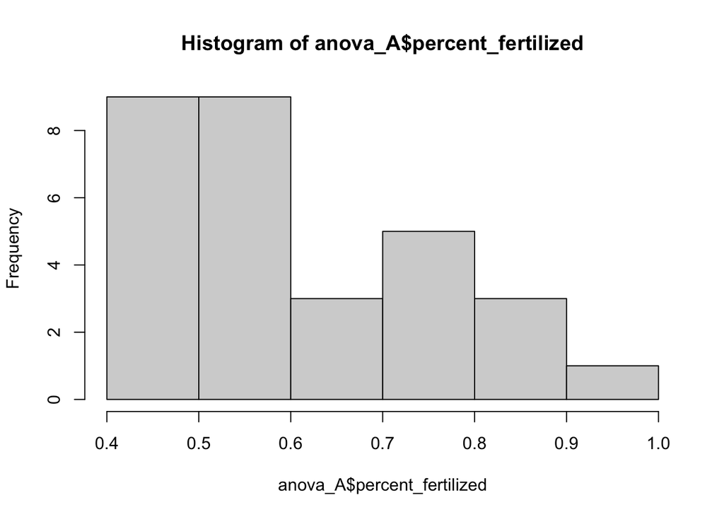

```r
hist(anova_A$percent_fertilized)
```

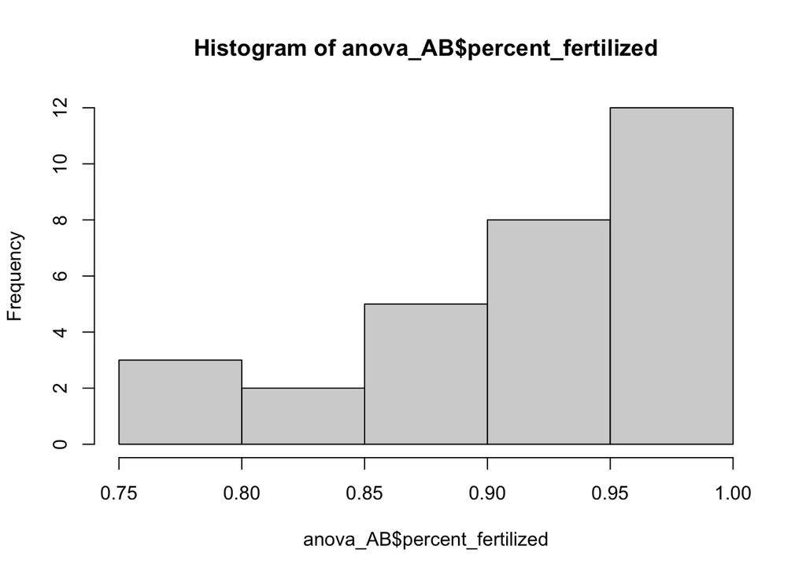

```r
hist(anova_AB$percent_fertilized)
```

.  
⇒ **Are the assumptions regarding data being normally distributed and variance being equal met? If not, what test is appropriate here instead?**  
Note, if the data is not normal, the Kruskal-Wallace test can be used (`kruskal.test(variable ~ group, data = dat)`). This will work even when the variances are unequal. If the data is normal, but the variances are unequal, the Welch ANOVA can be used (`oneway.test(variable ~ group, var.equal = FALSE)`)

```r
kruskal.test(anova_data$percent_fertilized ~ anova_data$genotype)
```

```
##
##  Kruskal-Wallis rank sum test
##
## data:  anova_data$percent_fertilized by anova_data$genotype
## Kruskal-Wallis chi-squared = 72.271, df = 2, p-value < 2.2e-16
```

```r
pairwise.wilcox.test(anova_data$percent_fertilized, anova_data$genotype,
                 p.adjust.method = "BH")
```

```
##
##  Pairwise comparisons using Wilcoxon rank sum test with continuity correction
##
## data:  anova_data$percent_fertilized and anova_data$genotype
##
##     WT      A
## A   1.2e-11 -
## A;B 6.4e-09 1.1e-09
##
## P value adjustment method: BH
```

## Error and Power

Recall that the power is $1−β$, where $β$ is the Type II error. We can calculate the power of the ANOVA test using the `command power.anova.test()`. The arguments for the command are:

**groups** = the number of groups in the dataset  
**n** = the number of observations per group  
**between.var** = sum of squares for between groups, $SS_{group}$  
**within.var** = sum of squares for within groups, $SS_{error}$  
**sig.level** = significance cutoff $α$ (Type I error)  
**power** = power of the test ($1−β = 1$ - Type II error)  
Given all of the arguments except for one, this function will return a value for the missing argument.

## Q7: Power of the ANOVA analysis

Given the data that we have been provided and the p-value we obtained, 6.17e-36, what is the power of our dataset? Remember to use the `power.anova.test()` function provided in the base R package (do NOT use the function from the pwr package).

```r
# first, check the documentation
help(power.anova.test)

# compute the power
power.anova.test(groups=3, n=30, within.var=SS_error, between.var=SS_group, sig.level=6.17e-36)
```

```
##
##      Balanced one-way analysis of variance power calculation
##
##          groups = 3
##               n = 30
##     between.var = 224667.6
##      within.var = 41238.43
##       sig.level = 6.17e-36
##           power = 0.02944547
##
## NOTE: n is number in each group
```

# Q8: Sample size

If we are happy with a power of $1−β=0.8$ and want to use a Type I error rate (significance cutoff) of $α=0.05$, how many observations for each group would we need?

```r
# compute the required sample size
power.anova.test(groups=3, within.var=SS_error, between.var=SS_group, sig.level=0.05, power=0.8)
```

```
##
##      Balanced one-way analysis of variance power calculation
##
##          groups = 3
##               n = 2.230741
##     between.var = 224667.6
##      within.var = 41238.43
##       sig.level = 0.05
##           power = 0.8
##
## NOTE: n is number in each group
```